# Data, Moyennes Mobiles et Temps Intrinsèque — Fiche de Révision Oral

- Contexte
- Vue d'ensemble
- Données réelles
- Moyennes mobiles
- Temps intrinsèque
- Questions oral
- Résumé
- Préparation 15min

# Data, Moyennes Mobiles et Temps Intrinsèque

Fiche de révision — Computational Finance (Master) — Examen oral

**🍕 Le problème du trader et de la pizza**  
Imaginez que vous surveillez le prix de la pizza margherita sur Deliveroo. À 11h, elle coûte 12€. À 11h03, elle passe à 12,50€. À 11h47, elle revient à 12€. Puis à 14h, elle explose à 18€ parce que tout le monde commande en même temps.  
Si vous prenez un point toutes les 30 minutes, vous rateriez complètement le pic de 14h. Si vous prenez un point toutes les secondes, vous vous noyez dans le bruit. Et si le livreur met à jour son prix à 11h03:27 et pas à 11h03:00, votre Excel va planter.  
**Bienvenue en finance quantitative : là où le temps est une illusion, et où la moyenne mobile est votre meilleure amie… ou votre pire ennemie.**

## 1. Vue d'ensemble

### Résumé du chapitre

Ce chapitre traite de la **réalité des données financières** (bruitées, asynchrones, non-équidistantes) et des outils pour les lisser : les **moyennes mobiles** (SMA, WMA, EMA). Il introduit ensuite le **temps intrinsèque** comme alternative au temps physique, fondée sur les événements de marché (changements directionnels de prix) plutôt que sur l'horloge.

### Concepts clés

#### Données réelles

- Bid/Ask spread
- Données non-équidistantes
- Bruit de marché (microstructure)
- Discrétisation vs Interpolation

#### Moyennes mobiles

- **SMA** : Simple Moving Average
- **WMA** : Weighted Moving Average
- **EMA** : Exponential Moving Average
- Compromis *lissage ↔ lag*
- Choix de $\alpha$ et conditions initiales

#### Temps intrinsèque

- Temps physique = arbitraire
- Événements = changements directionnels (DC)
- Overshoot (OS) = continuation après DC
- Scaling laws : lien temps physique ↔ intrinsèque

#### Ce qu'il faut absolument retenir

- SMA $\neq$ EMA même avec $\alpha = 2/(n+1)$
- EMA est récursive et élégante
- Temps intrinsèque = adaptation au régime de volatilité
- Plus on lisse, plus le lag augmente

— Contenu détaillé —

## 2. Données en finance réelle

### Concept

En théorie, on imagine une série temporelle **équidistante, lisse et continue**. En pratique, les données financières sont :

- **Non-équidistantes** : beaucoup de ticks en période de volatilité, peu la nuit
- **Bruitées** : bid/ask spread, microstructure de marché
- **Possiblement discontinues** : sauts de prix, gaps overnight

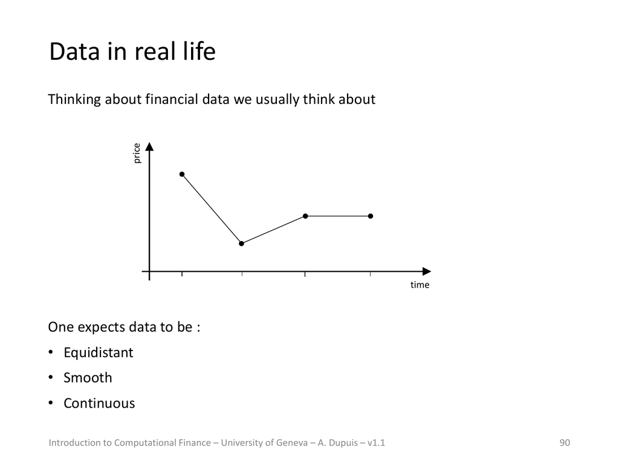

Figure 1 — Le rêve du quant : données équidistantes, lisses et continues.

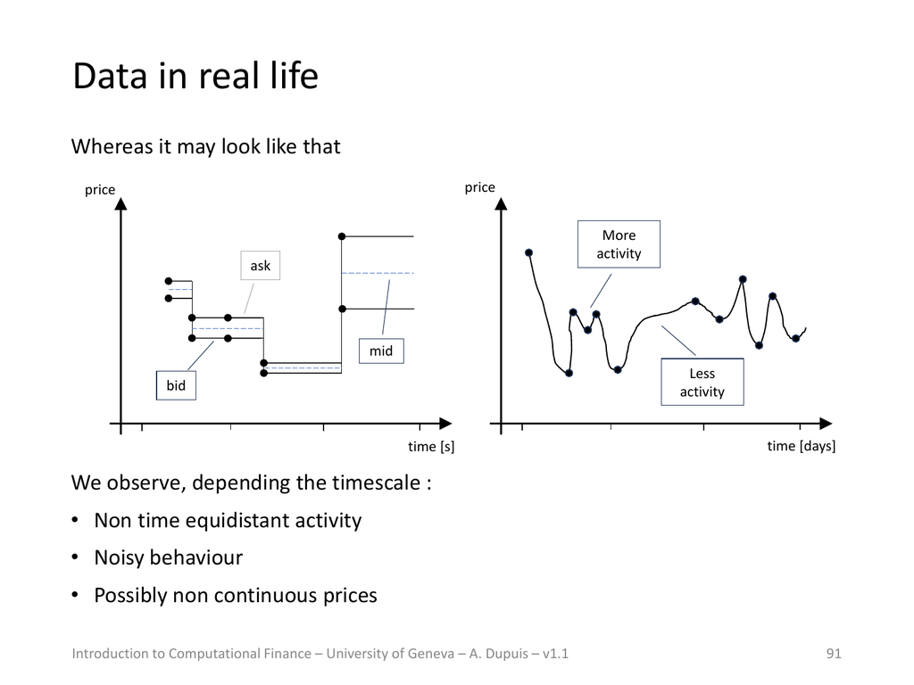

Figure 2 — La réalité : bid/ask (gauche) et activité hétérogène (droite). À gauche : chaque tick a un bid, un ask et un mid. À droite : "More activity" = plus de variance locale.

**💡 Intuition :** Le prix "mid" (moyenne bid/ask) est souvent utilisé comme proxy du prix de transaction, mais il reste bruité par le spread. L'activité n'est pas uniforme : le marché "respire" différemment selon les heures.

### Comment traiter ces données ?

#### 1. Discrétisation (99,9% des cas)

On prend un snapshot à intervalles réguliers (ex: toutes les 5 min). **Problème :** on ignore l'information entre les ticks et on rate les tendances locales.

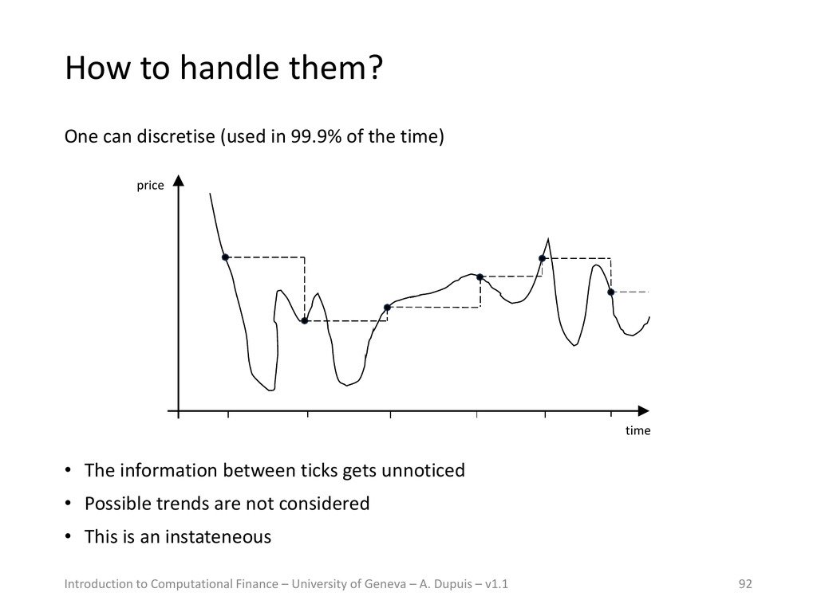

Figure 3 — Discrétisation : perte d'information entre les points.

#### 2. Interpolation (rare)

On tire une courbe entre les points observés. **Problème :** hypothèses fortes sur la dynamique entre les observations. Le temps physique reste rigide.

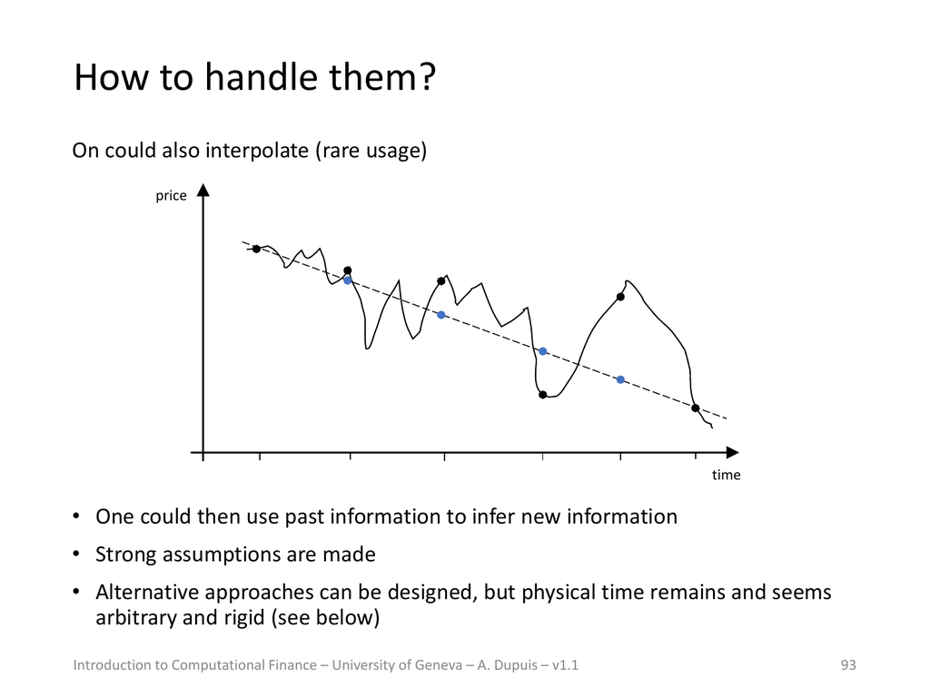

Figure 4 — Interpolation : hypothèses sur la trajectoire entre ticks.

**⚠️ Piège fréquent :** La discrétisation masque la microstructure. Si l'examinateur demande "qu'est-ce qui se passe entre 10h00 et 10h05 ?", la réponse est : *"On ne sait pas, on a jeté l'information."*

— Moyennes Mobiles —

## 3. Moyennes Mobiles (Moving Averages)

Objectif : **lisser** la série temporelle pour réduire le bruit et mettre en évidence la tendance. Mais attention : le lissage crée toujours un lag (décalage temporel).

### 3.1 Simple Moving Average (SMA)

$$ SMA(t) = \frac{1}{n} \sum_{i=0}^{n-1} X_{t-i} = \frac{X_{t-n+1} + X_{t-n+2} + \cdots + X_t}{n} $$

Formule de base **$X_t$** : valeur de la série à l'instant $t$.  
**$n$** : taille de la fenêtre glissante (nombre d'observations).  
**Intuition** : moyenne arithmétique des $n$ dernières observations. Chaque point a le même poids $1/n$.

$$ SMA(t+1) = SMA(t) - \frac{X_{t-n+1}}{n} + \frac{X_{t+1}}{n} $$

Mise à jour efficace **Intuition** : on retire le point le plus ancien (sort de la fenêtre) et on ajoute le nouveau. Complexité $O(1)$ par mise à jour, mais il faut garder les $n$ dernières valeurs en mémoire.

**⚠️ Problèmes de la SMA :**

1. **Poids uniforme** : une observation vieille de $n$ jours compte autant que celle d'aujourd'hui. Absurde en finance.
2. **Lag temporel** : plus $n$ est grand, plus le lag est important. La SMA "traîne" derrière la série.

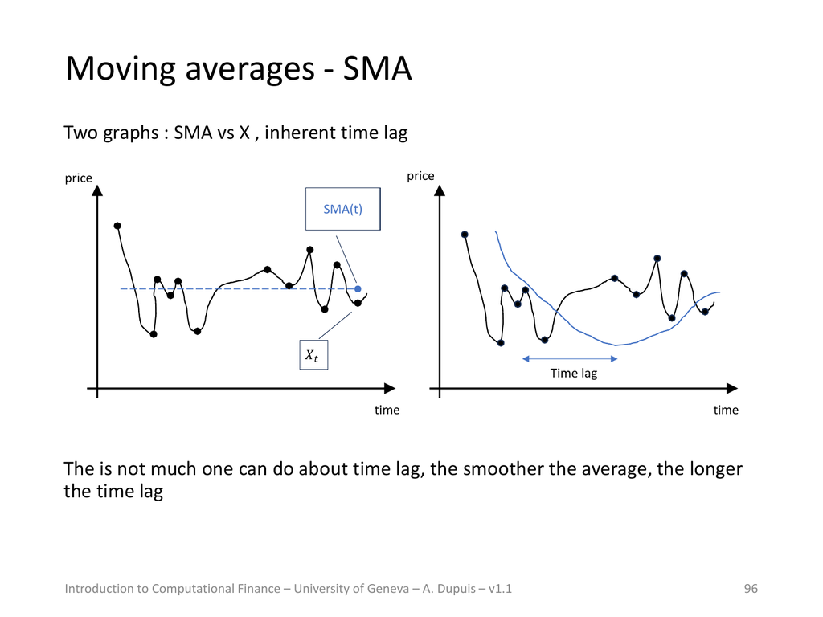

Figure 5 — SMA vs série originale $X_t$ (gauche) et illustration du lag temporel (droite). La courbe bleue est décalée vers la droite : elle réagit avec retard.

**💡 Pour l'oral :** "La SMA est simple mais naïve : elle donne le même poids à un prix d'il y a 100 jours qu'à celui d'hier. En finance, l'information récente est plus pertinente."

### 3.2 Weighted Moving Average (WMA)

Solution au problème de poids : donner plus d'importance aux observations récentes.

$$ WMA(t) = \frac{1\cdot X_{t-n+1} + 2\cdot X_{t-n+2} + \cdots + (n-1)\cdot X_{t-1} + n\cdot X_t}{1 + 2 + \cdots + n} = \frac{2}{n(n+1)} \sum_{i=1}^{n} i \cdot X_{t-n+i} $$

$$ WMA(t+1) = \frac{(1\cdot X_{t-n+1} + \cdots + (n-1)\cdot X_{t-1} + n\cdot X_t) + n\cdot X_{t+1} - Total(t)}{n(n+1)/2} $$ où $Total(t) = \sum_{i=0}^{n-1} X_{t-i}$

Mise à jour **Intuition** : la mise à jour est plus complexe que la SMA car les poids changent. Il faut maintenir à la fois la somme pondérée et la somme simple $Total(t)$.

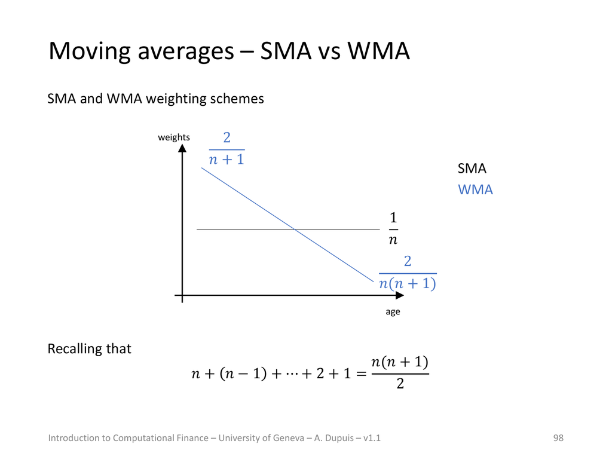

Figure 6 — Schéma des poids : SMA = constante ($1/n$), WMA = linéaire décroissant de $2/(n+1)$ à $2/(n(n+1))$.

### 3.3 Exponential Moving Average (EMA)

La solution la plus élégante : décroissance **exponentielle** des poids, formule récursive simple.

$$ EMA(t) = \alpha X_t + (1-\alpha) EMA(t-1) $$

Formule récursive **$\alpha \in ]0,1[$** : facteur de lissage (smoothing factor).  
**$X_t$** : valeur actuelle.  
**$EMA(t-1)$** : valeur précédente de l'EMA.  
**Intuition** : on fait une moyenne entre la valeur actuelle (pondérée par $\alpha$) et l'historique lissé (pondéré par $1-\alpha$). C'est un **filtre passe-bas** du premier ordre.

**📐 Voir les détails mathématiques (forme infinie de l'EMA)**

On peut démontrer que la forme récursive correspond à une somme infinie pondérée :

$$ EMA(t) = \frac{X_t + (1-\alpha)X_{t-1} + (1-\alpha)^2 X_{t-2} + \cdots}{1 + (1-\alpha) + (1-\alpha)^2 + \cdots} = \alpha \sum_{i=0}^{\infty} (1-\alpha)^i X_{t-i} $$

Le dénominateur est une série géométrique : $\sum_{i=0}^{\infty} (1-\alpha)^i = \frac{1}{\alpha}$.

Chaque observation passée est pondérée par $(1-\alpha)^i$ où $i$ est son âge. Plus $\alpha$ est grand, plus les poids décroissent vite (plus on privilégie le présent).

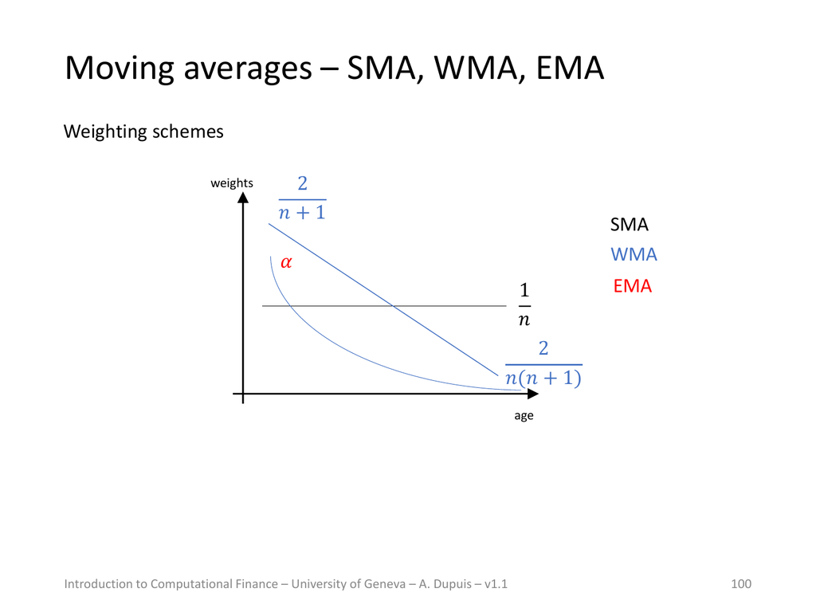

Figure 7 — Schéma des poids selon l'âge de l'observation. SMA = constante, WMA = linéaire décroissant, EMA = exponentiel décroissant (départ à $\alpha$).

### 3.4 Conditions initiales et choix de $\alpha$

#### Conditions initiales

- **SMA et WMA** : besoin de $n$ observations pour démarrer. Pas de valeur avant $t=n$.
- **EMA** : plusieurs choix possibles :
  - $EMA(1) = X_1$ (initialisation simple, mais biaisée au début)
  - $EMA(n) = SMA(n)$ (attendre $n$ observations, puis basculer sur EMA)

#### Comment choisir $\alpha$ ?

**Méthode 1 : équivalence avec SMA (âge moyen)**

$$ \alpha = \frac{2}{n+1} $$

On égale l'âge moyen des observations dans une SMA de fenêtre $n$ et dans l'EMA. L'âge moyen de la SMA est $\frac{n+1}{2}$, celui de l'EMA est $\frac{1}{\alpha}$.  
Attention : SMA $\neq$ EMA même avec cette relation ! Ce n'est qu'une équivalence d'âge moyen.

**Méthode 2 : impact après $k$ pas**

$$ (1-\alpha)^k = \epsilon_k \quad \Rightarrow \quad \alpha = 1 - e^{\frac{\ln(\epsilon_k)}{k}} $$

Exemple : on veut que l'impact d'une observation soit réduit à 1% après $k=100$ pas. $$ \alpha = 1 - e^{\frac{\ln(0.01)}{100}} \approx 0.045 $$ À comparer avec la méthode 1 : pour $n=100$, $\alpha = \frac{2}{101} \approx 0.0198$. Les deux méthodes donnent des résultats très différents !

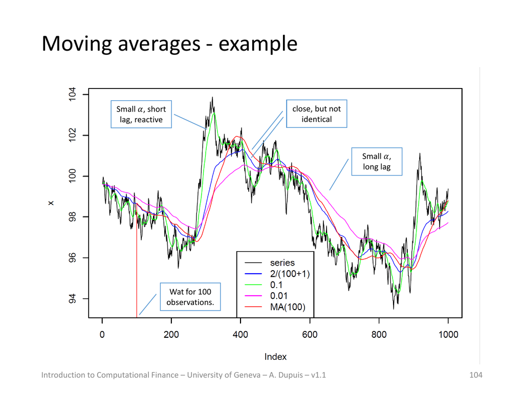

Figure 8 — Comparaison de différentes EMA et SMA(100). Vert ($\alpha=0.1$) : très réactive, peu de lag. Magenta ($\alpha=0.01$) : très lissée, gros lag. Bleu ($\alpha=2/101$) : proche de SMA(100) mais pas identique.

### 3.5 Extension : données asynchrones

Et si les données arrivent à des intervalles irréguliers ? (ex: market maker activity)

$$ EMA[\tau; x](t_n) = \mu \cdot EMA[\tau; x](t_{n-1}) + (\nu - \mu) x_{n-1} + (1 - \nu) x_n $$

EMA pour données asynchrones **$\tau$** : échelle de temps caractéristique.  
**$\alpha = (t_n - t_{n-1})/\tau$** : pas de temps adimensionné.  
**$\mu = e^{-\alpha}$** : décroissance exponentielle liée au temps écoulé.  
**$\nu = \frac{1-\mu}{\alpha}$** : facteur d'interpolation.  
**Intuition** : entre deux observations, on interpole linéairement. Si $\Delta t$ est grand, $\mu$ est petit et l'ancienne valeur est fortement oubliée.

**💡 Intuition :** Cette formule généralise l'EMA classique. Si $\Delta t$ est constant, on retrouve la formule standard avec $\alpha$ fixe. Si $\Delta t \to 0$, $\mu \to 1$ et on conserve presque l'ancienne valeur.

$$ EMA[\tau, n; x] = EMA[\tau; EMA[\tau, n-1; x]] \quad \text{(EMA itérée)} $$ $$ SMA[\tau, n] = \frac{1}{n} \sum_{k=1}^{n} EMA[\tau'; k] \quad \text{avec} \quad \tau' = \frac{2\tau}{n+1} $$

**EMA itérée** : appliquer l'EMA plusieurs fois pour plus de lissage.  
**SMA en temps intrinsèque** : moyenne d'EMAs avec des échelles de temps adaptées.

— Temps Intrinsèque —

## 4. Temps Intrinsèque (Intrinsic Time)

### Concept

Le **temps physique** (l'horloge) est arbitraire en finance :

- Pourquoi commencer à minuit ? Pourquoi pas à 17h ?
- Le marché est dormant la nuit, hyperactif à l'ouverture.
- Des événements importants peuvent se produire entre deux observations et passer inaperçus.

**💡 Analogie :** Le temps physique c'est comme mesurer la distance en fonction du temps de marche. Mais si vous marchez vite un jour et lentement le lendemain, la distance parcourue n'est pas la même. Le marché "marche" vite quand il est volatil, lent quand il est calme.

**Solution :** Le temps devrait être dicté par les **événements de marché**, pas par l'horloge.

### Définition : Changements Directionnels (Directional Changes, DC)

On définit un **événement** comme un changement de direction du prix d'une amplitude $\delta$ donnée. Entre deux événements, on observe l'**overshoot** (OS).

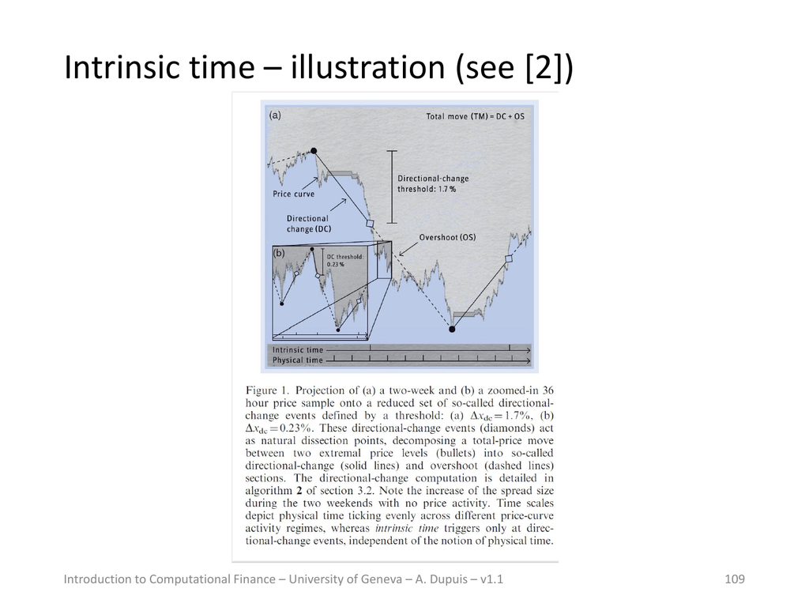

Figure 9 — Temps intrinsèque vs temps physique. Les événements (diamants) sont les changements directionnels. Les bullets = extrema locaux. TM (Total Move) = DC + OS. Le temps intrinsèque ne tic que lors des DC, indépendamment du temps physique.

#### Vocabulaire clé

- **DC (Directional Change)** : le mouvement directionnel jusqu'au point de retournement.
- **OS (Overshoot)** : le mouvement au-delà du DC, jusqu'au prochain extrémum.
- **TM (Total Move)** : $TM = DC + OS$ = mouvement total entre deux extrema.
- **$\delta$** : seuil de détection du changement directionnel (ex: 1.7%, 0.23%).

**⚠️ Piège :** Plus $\delta$ est petit, plus on détecte d'événements, plus le temps intrinsèque "accélère". C'est un **paramètre de zoom** : petit $\delta$ = microscope, grand $\delta$ = télescope.

### Algorithme de détection

**Initialisation :** mode = "up", $M_{ext}$ = prix initial, $C_{ext}$ = prix initial.

**Pour chaque tick :**

- Si mode = "up" :
  - Si prix < $M_{ext}$ : $M_{ext}$ = prix (nouveau minimum local)
  - Sinon si prix - $M_{ext}$ > $\delta$ : **Nouveau DC down !** $M_{ext}$ = prix, mode = "down"
- Si mode = "down" :
  - Si prix > $M_{ext}$ : $M_{ext}$ = prix (nouveau maximum local)
  - Sinon si $M_{ext}$ - prix > $\delta$ : **Nouveau DC up !** $M_{ext}$ = prix, mode = "up"

**💡 Intuition algorithmique :** On suit la tendance actuelle. Tant que le prix continue dans la direction, on met à jour l'extrémum. Dès que le prix revient de $\delta$ par rapport à cet extrémum, on déclare un changement de direction.

### Scaling Laws (Lois d'échelle)

Comment relier le temps intrinsèque au temps physique ? On observe des **relations de puissance** (scaling laws) empiriquement vérifiées sur les données de marché.

$$ \langle |\Delta x| \rangle \sim \Delta t^{\alpha} $$ $$ \langle \Delta t_{dc} \rangle \sim \left(\frac{\delta}{c}\right)^{\alpha} $$

**Première loi** : le mouvement de prix moyen évolue en puissance du temps physique.  
**Deuxième loi** : le temps moyen passé dans un DC dépend du seuil $\delta$ selon une loi de puissance.  
**$\alpha$** : exposant de scaling (souvent proche de 0.5 pour un Brownien, mais différent en réalité).

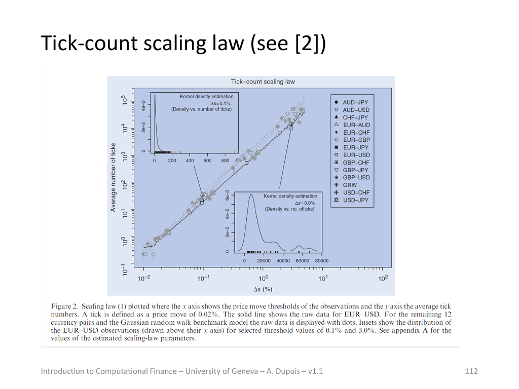

Figure 10 — Tick-count scaling law. Nombre moyen de ticks en fonction du seuil de mouvement $\Delta x$ (%). La relation est linéaire en log-log, signe d'une loi de puissance. Insets : distributions du nombre de ticks pour $\Delta x = 0.1\%$ (asymétrique, queue lourde) et $\Delta x = 3.0\%$ (plus symétrique).

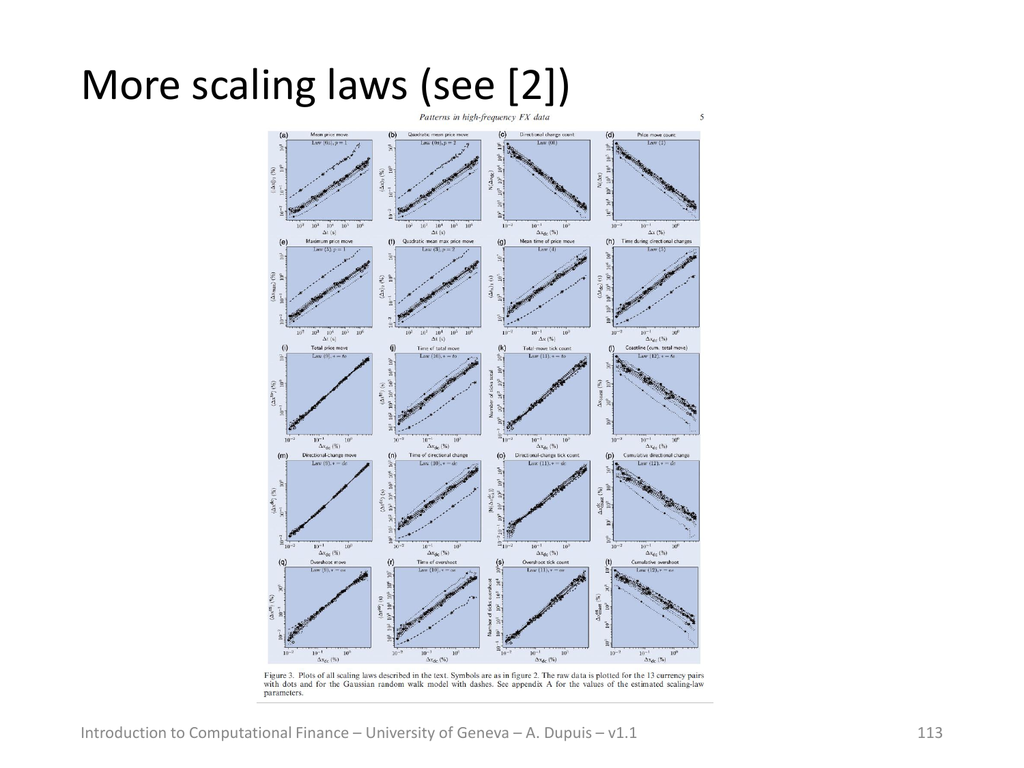

#### Interprétation des scaling laws

- **Mean price move** : $\langle |\Delta x| \rangle \sim \Delta t^{1/2}$ pour un Brownien, mais les marchés réels peuvent avoir d'autres exposants.
- **Directional change count** : $N(\Delta x_{dc}) \sim \Delta x_{dc}^{-2}$ — plus le seuil est petit, plus il y a d'événements (quadratiquement).
- **Time during DC** : durée moyenne d'un DC en fonction du seuil.
- **Overshoot** : longueur moyenne de l'overshoot liée à la liquidité.

**💡 Pour l'oral :** "Les scaling laws montrent que le marché a une structure fractale/self-similaire. Quelle que soit l'échelle de temps ($\delta$), on observe les mêmes types de relations. C'est l'empreinte d'un processus avec mémoire et hétéroscédasticité, pas d'un simple Brownien."

— Questions d'oral —

## 5. Questions d'oral possibles

#### ❓ Pourquoi le temps physique est-il problématique en finance ?

**Réponse type :** Le temps physique est arbitraire (pourquoi minuit ?) et rigide. Il ne reflète pas l'activité du marché : la nuit, peu de trades ; à l'ouverture, beaucoup. De plus, entre deux observations régulières, des événements importants peuvent être manqués. Le temps physique favorise l'information à haute fréquence au détriment de la signification.

#### ❓ Qu'est-ce que le temps intrinsèque ? Définissez DC et OS.

**Réponse type :** Le temps intrinsèque est une mesure du temps basée sur les événements de marché, pas sur l'horloge. Un **DC (Directional Change)** est déclenché quand le prix change de direction d'un seuil $\delta$. L'**OS (Overshoot)** est le mouvement au-delà de ce point de retournement jusqu'au prochain extrémum. Le temps ne "tic" que lors des DC. C'est adaptatif : volatilité élevée = temps intrinsèque rapide.

#### ❓ Que nous apprennent les scaling laws ?

**Réponse type :** Elles établissent des relations quantitatives entre le temps physique et le temps intrinsèque. Par exemple, le nombre de ticks moyens dans un mouvement de prix $\Delta x$ suit une loi de puissance. Cela montre que les marchés ont une structure **self-similaire** (fractale) : les mêmes patterns apparaissent à toutes les échelles. C'est aussi un test : si les données ne suivent pas ces lois, elles ne sont pas "typiques" de la microstructure des marchés.

— Résumé ultra-rapide —

## 6. Résumé ultra-rapide

### 🎯 Fiche de révision condensée

1

**Données réelles** : bid/ask, non-équidistantes, bruitées. Discrétisation = perte d'info. Interpolation = hypothèses fortes.

2

**SMA** : $SMA(t) = \frac{1}{n}\sum_{i=0}^{n-1} X_{t-i}$. Poids uniforme. Lag important. Besoin de $n$ valeurs en mémoire.

3

**WMA** : poids linéaires croissants. $WMA(t) = \frac{2}{n(n+1)}\sum_{i=1}^n i X_{t-n+i}$. Mise à jour complexe.

4

**EMA** : $EMA(t) = \alpha X_t + (1-\alpha)EMA(t-1)$. Poids exponentiels décroissants. Récursive, mémoire $O(1)$. Choix $\alpha = 2/(n+1)$ (équivalence d'âge) ou par impact cible.

5

**Compromis fondamental** : plus on lisse, plus le lag augmente. Inévitable. EMA avec petit $\alpha$ = très lisse, très retardée.

6

**Temps intrinsèque** : basé sur les événements (DC), pas l'horloge. DC = changement de direction de seuil $\delta$. OS = continuation après DC. Temps adaptatif à la volatilité.

7

**Scaling laws** : relations de puissance entre quantités physiques et intrinsèques. Ex : $\langle \Delta t_{dc} \rangle \sim (\delta/c)^\alpha$. Signe de self-similarité et de microstructure stable.

⚠️

**Erreurs à éviter** : (a) SMA = EMA ? Jamais ! (b) $\alpha$ grand = lissage ? Non, c'est l'inverse ! (c) Initialisation EMA sans biais ? Impossible, il faut du temps pour converger.

— Préparation 15 min —

## 7. Feuille de préparation (15 minutes avant l'examen)

### 📝 "Ce que j'écris sur ma feuille dès le début de la préparation"

#### Formules absolues

F1

$SMA(t) = \frac{1}{n}\sum_{i=0}^{n-1} X_{t-i}$ | Update : $SMA(t+1) = SMA(t) - \frac{X_{t-n+1}}{n} + \frac{X_{t+1}}{n}$

F2

$WMA(t) = \frac{2}{n(n+1)}\sum_{i=1}^n i X_{t-n+i}$

F3

$EMA(t) = \alpha X_t + (1-\alpha)EMA(t-1)$ | $\alpha = \frac{2}{n+1}$ (équivalence âge)

F4

$EMA[\tau;x](t_n) = \mu EMA(t_{n-1}) + (\nu-\mu)x_{n-1} + (1-\nu)x_n$ avec $\mu = e^{-\alpha}$, $\nu = \frac{1-\mu}{\alpha}$

#### Concepts-clés (check-list)

✓

**3 types de MA** : SMA (uniforme), WMA (linéaire), EMA (exponentiel). EMA = la plus élégante.

✓

**Trade-off** : lissage $\uparrow$ $\Rightarrow$ lag $\uparrow$. Inévitable.

✓

**Temps physique** : arbitraire, rigide, ignore la microstructure.

✓

**Temps intrinsèque** : événements = DC (changements directionnels de seuil $\delta$). OS = overshoot.

✓

**Scaling laws** : liens puissance entre temps physique et intrinsèque. Self-similarité des marchés.

#### Relations importantes

→

Petit $\alpha$ (EMA) $\equiv$ grand $n$ (SMA) : lissage fort, lag long.

→

Grand $\alpha$ (EMA) $\equiv$ petit $n$ (SMA) : réactif, peu de lissage.

→

Petit $\delta$ (temps intrinsèque) $\Rightarrow$ beaucoup d'événements $\Rightarrow$ temps "accéléré".

→

EMA asynchrone : $\Delta t$ grand $\Rightarrow$ $\mu$ petit $\Rightarrow$ oubli rapide.

#### Points à ne surtout pas oublier

🔥

**SMA $\neq$ EMA** même avec $\alpha = 2/(n+1)$. C'est une équivalence d'âge moyen, pas une égalité.

🔥

**L'EMA a besoin d'un warm-up**. Les premières valeurs sont biaisées par l'initialisation.

🔥

**Le temps intrinsèque n'est pas une interpolation**. C'est une re-paramétrisation basée sur les prix.

🔥

**Les scaling laws sont empiriques**. Elles caractérisent la microstructure, ce ne sont pas des théorèmes.

🔥

**Discrétisation $\neq$ Interpolation**. La première jette l'info, la seconde invente l'info.

**🎤 Dernière minute :** Si l'examinateur vous met la pression, respirez et dites : *"Le cœur de ce chapitre est le compromis entre lissage et réactivité. La SMA est naïve, l'EMA est élégante, et le temps intrinsèque nous rappelle que l'horloge n'est pas le meilleur référentiel pour le marché."* Cela couvre 80% des attentes.